# 9.2(a): Multiple coins from a single mint

## Introduction

This is the first of three models in Section 9.2 of Kruschke. It makes a weak claim about the value of $\omega$, and a weak dependence of $\theta$ on $\omega$.

## Preliminaries

Load necessary packages:

```r
library(rstan)
library(shinystan)
library(bayesplot)
```

Set Stan to save compiled code.

```r
rstan_options(auto_write = TRUE)
```

Set Stan to use parallel processing where possible.

```r
options(mc.cores = parallel::detectCores())
```

## Data

Instead of recording individual coin flips (which is tricky data to work with given that each coin is flipped a different number of times), for this example we’ll record only the total number of successes (heads) from each coin.

```r
S <- 2 # 2 coins
N1 <- 15
N2 <- 5
N <- c(N1, N2)
y1 <- 3 # 3 heads (of 15)
y2 <- 4 # 4 heads (of 5)
y <- c(y1, y2)
stan_data <- list(S = S, N = N, y = y)
```

## Stan code

To accomodate the different form of the data, we define `S` to be the number of coins (2 here, but this could be generalized to any number of coins) and create arrays `N[S]` and `y[S]` to hold the number of trials and the number of heads.

```stan
data {
    int<lower = 0> S;
    int<lower = 0> N[S];
    int<lower = 0> y[S];
}
transformed data {
    real<lower = 0> A_omega;
    real<lower = 0> B_omega;
    real<lower = 0> K;

    A_omega = 2;
    B_omega = 2;
    K = 5;
}
parameters {
    real<lower = 0, upper = 1> omega;
    real<lower = 0, upper = 1> theta[S];
}
transformed parameters {
    real<lower = 0> a;
    real<lower = 0> b;

    a = omega * (K - 2) + 1;
    b = (1 - omega) * (K - 2) + 1;
}
model {
    omega ~ beta(A_omega, B_omega);
    theta ~ beta(a, b);
    y ~ binomial(N, theta);
}
generated quantities {
    int<lower = 0> y_rep[S];

    for (s in 1:S) {
        y_rep[s] = binomial_rng(N[s], theta[s]);
    }
}
```

## Sampling from the model

```r
set.seed(11111)
fit_mcsma <- sampling(mcsma, data = stan_data, refresh = 0)
```

## Diagnosing the model

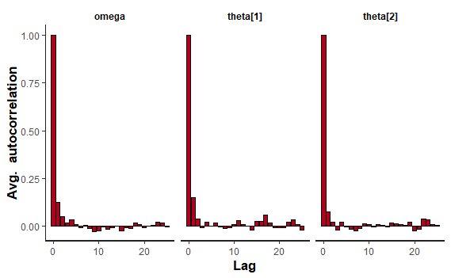

```r
plot(fit_mcsma, plotfun = "ac", pars = c("omega", "theta"))
```

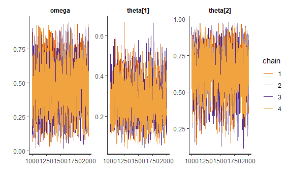

```r
plot(fit_mcsma, plotfun = "trace",
     pars = c("omega", "theta"))
```

## Summarizing the model

```r
fit_mcsma
```

```
Inference for Stan model: stan-41981aa251a5.
4 chains, each with iter=2000; warmup=1000; thin=1;
post-warmup draws per chain=1000, total post-warmup draws=4000.

           mean se_mean   sd   2.5%    25%    50%    75%  97.5%
omega      0.47    0.00 0.19   0.12   0.32   0.46   0.61   0.82
theta[1]   0.27    0.00 0.10   0.11   0.20   0.26   0.34   0.48
theta[2]   0.64    0.00 0.15   0.31   0.54   0.65   0.75   0.91
a          2.40    0.01 0.57   1.35   1.97   2.38   2.82   3.47
b          2.60    0.01 0.57   1.53   2.18   2.62   3.03   3.65
y_rep[1]   4.07    0.04 2.24   0.00   2.00   4.00   6.00   9.00
y_rep[2]   3.19    0.02 1.28   1.00   2.00   3.00   4.00   5.00
lp__     -17.36    0.03 1.26 -20.74 -17.94 -17.05 -16.43 -15.88
         n_eff Rhat
omega     2716    1
theta[1]  2748    1
theta[2]  3463    1
a         2716    1
b         2716    1
y_rep[1]  3442    1
y_rep[2]  3885    1
lp__      1853    1

Samples were drawn using NUTS(diag_e) at Sun May 26 15:42:38 2019.
For each parameter, n_eff is a crude measure of effective sample size,
and Rhat is the potential scale reduction factor on split chains (at
convergence, Rhat=1).
```

## Visualizing the model

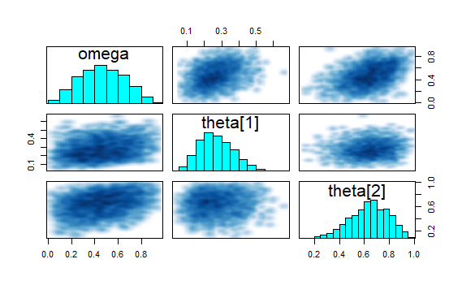

```r
pairs(fit_mcsma, pars = c("omega", "theta"))
```

```
ci_level: 0.8 (80% intervals)
outer_level: 0.95 (95% intervals)
```

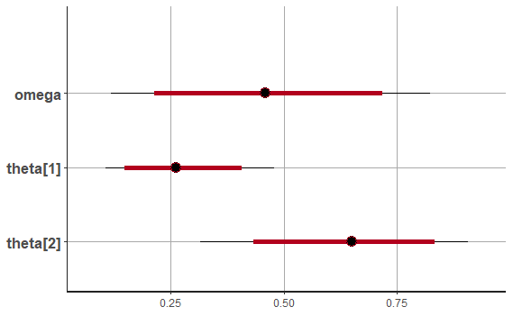

```r
plot(fit_mcsma, pars = c("omega", "theta"))
```

With a weak prior on $\omega$, the data from each coin pulls its respective value of $\theta$ closer to the proportion of successes for that coin.

## Examining the prior

```stan
data {
    int<lower = 0> S;
    int<lower = 0> N[S];
    int<lower = 0> y[S];
}
transformed data {
    real<lower = 0> A_omega;
    real<lower = 0> B_omega;
    real<lower = 0> K;

    A_omega = 2;
    B_omega = 2;
    K = 5;
}
parameters {
    real<lower = 0, upper = 1> omega;
    real<lower = 0, upper = 1> theta[S];
}
transformed parameters {
    real<lower = 0> a;
    real<lower = 0> b;

    a = omega * (K - 2) + 1;
    b = (1 - omega) * (K - 2) + 1;
}
model {
    omega ~ beta(A_omega, B_omega);
    theta ~ beta(a, b);
//    y ~ binomial(N, theta);
}
```

```r
set.seed(11111)
fit_mcsma_prior <- sampling(mcsma_prior, data = stan_data, refresh = 0)
```

```r
fit_mcsma_prior
```

```
Inference for Stan model: stan-419838601f00.
4 chains, each with iter=2000; warmup=1000; thin=1;
post-warmup draws per chain=1000, total post-warmup draws=4000.

          mean se_mean   sd  2.5%   25%   50%   75% 97.5% n_eff
omega     0.50    0.00 0.22  0.10  0.32  0.50  0.67  0.90  2323
theta[1]  0.50    0.00 0.24  0.06  0.31  0.50  0.68  0.94  2723
theta[2]  0.50    0.00 0.24  0.07  0.32  0.50  0.68  0.92  2552
a         2.49    0.01 0.67  1.30  1.97  2.49  3.01  3.70  2323
b         2.51    0.01 0.67  1.30  1.99  2.51  3.03  3.70  2323
lp__     -6.24    0.04 1.41 -9.87 -6.90 -5.88 -5.20 -4.60  1611
         Rhat
omega       1
theta[1]    1
theta[2]    1
a           1
b           1
lp__        1

Samples were drawn using NUTS(diag_e) at Sun May 26 15:44:15 2019.
For each parameter, n_eff is a crude measure of effective sample size,
and Rhat is the potential scale reduction factor on split chains (at
convergence, Rhat=1).
```

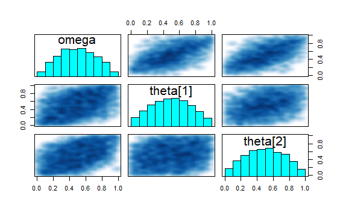

```r
pairs(fit_mcsma_prior, pars = c("omega", "theta"))
```

```
ci_level: 0.8 (80% intervals)
outer_level: 0.95 (95% intervals)
```

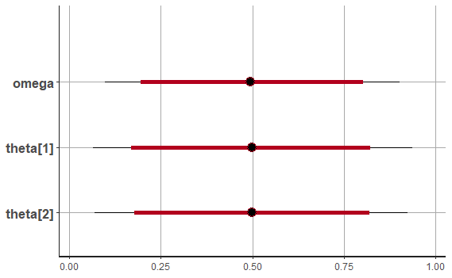

```r
plot(fit_mcsma_prior, pars = c("omega", "theta"))
```

## Posterior predictive check

Extract predicted values:

```r
samples_mcsma <- extract(fit_mcsma)
y_rep <- samples_mcsma$y_rep
```

Graph values of $y$ against summaries of $y_{rep}$.

(The `ppc_stat` function requires a matrix as input, so we have to convert the single columns of values in `y_rep[, 1]` to a 4000 by 1 matrix.)

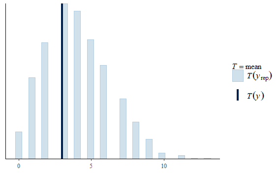

```r
ppc_stat(y[1], as.matrix(y_rep[ , 1]))
```

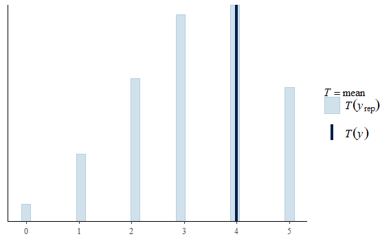

```r
ppc_stat(y[2], as.matrix(y_rep[ , 2]))
```

The $x$ value in the graph below simply identifies the two coins.

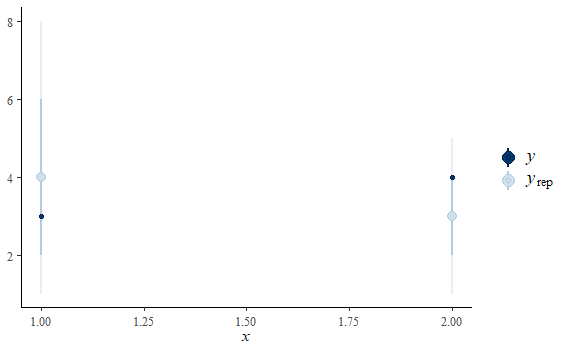

```r
ppc_intervals(y, y_rep)
```

Notice the shrinkage: the replicated data is partway between the actual data and the prior for each coin.

## ShinyStan

Run the following code from the Console:

```
launch_shinystan(fit_mcsma)
```